# Automatic units in axis labels

Edzer Pebesma

05 December, 2016

TOC

This blog post concerns the development version of units, installed by

```r
devtools::install_github("edzer/units")
```

Have you ever tried to properly add measurement units to R plots? It might go like this:

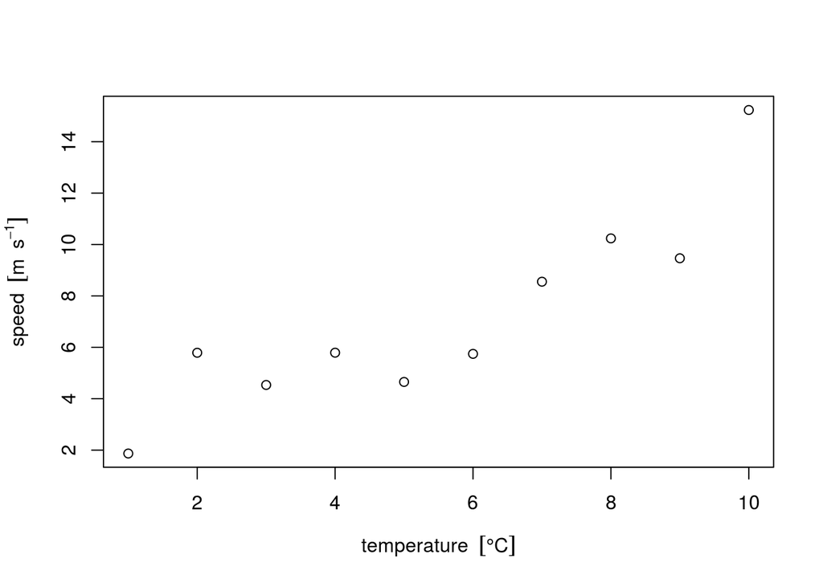

```r
xlab = parse(text = "temperature ~~ group('[', degree * C, ']')")
ylab = parse(text = "speed ~~ group('[', m * ~~ s^-1, ']')")
par(mar = par("mar") + c(0, .3, 0, 0)) # avoids cutting of superscript
plot(3 + 1:10 + 2 * rnorm(10), xlab = xlab, ylab = ylab)
```

The main observation is, of course that *it can be done*. However,

- it looks geeky, and not quite intuitive
- you would typically postpone this work to just before submitting the paper, or during review
- you need this so infrequently that you tend to forget how it works.

Although well-written help is found in `?plotmath`, all three observations cause frustration.

The [original paper](http://www.stat.washington.edu/fritz/DATAFILES498B2008/MathinR.pdf) desribing `plotmath` is by Paul Murrell and Ross Ihaka. [R core](https://www.r-project.org/contributors.html) member Paul Murrell also wrote package `grid`, part of base R. Few people use it directly, but without it ggplot2 or lattice could not exist.

## Automatic unit handling

The new units CRAN package now makes working with units

- easier
- automatic, and
- less error-prone

Here is an example using `mtcars`. First, we specify the imperial units to those known in the [udunits2](https://www.unidata.ucar.edu/software/udunits/udunits-2.2.20/doc/udunits/udunits2.html#Database) database:

```r
library(units)
gallon = make_unit("gallon")
consumption = mtcars$mpg * with(ud_units, mi/gallon)
displacement = mtcars$disp * ud_units[["in"]]^3
```

For `displacement`, we cannot use the normal lookup in the database

```r
displacement = mtcars$disp * with(ud_units, in)
```

because `in` (inch) is also a reserved word in R.

We convert these values to SI units by

```r
units(displacement) = with(ud_units, cm^3)
units(consumption) = with(ud_units, km/l)
consumption[1:5]
```

```
## Units: km/l
## [1] 8.928017 8.928017 9.693276 9.098075 7.950187
```

## Automatic measurement units in axis labels

We can plot these numeric variabes of type `units` by

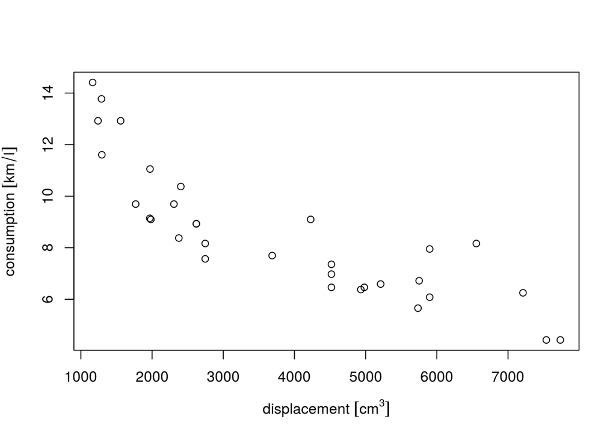

```r
par(mar = par("mar") + c(0, .1, 0, 0)) # avoids cutting of brackets at lhs
plot(displacement, consumption)
```

The units automatically appear in axis labels! If we want to have negative power instead of division bars, we can set a global option

```r
units_options(negative_power = TRUE) # division becomes ^-1
```

Expressions such as

```r
1/displacement [1:10]
```

```
## Units: cm^-3
##  [1] 0.0003813984 0.0003813984 0.0005650347 0.0002365261 0.0001695104
##  [6] 0.0002712166 0.0001695104 0.0004159764 0.0004334073 0.0003641035
```

automatically convert units, which also happens in plots (note the converted units symbols):

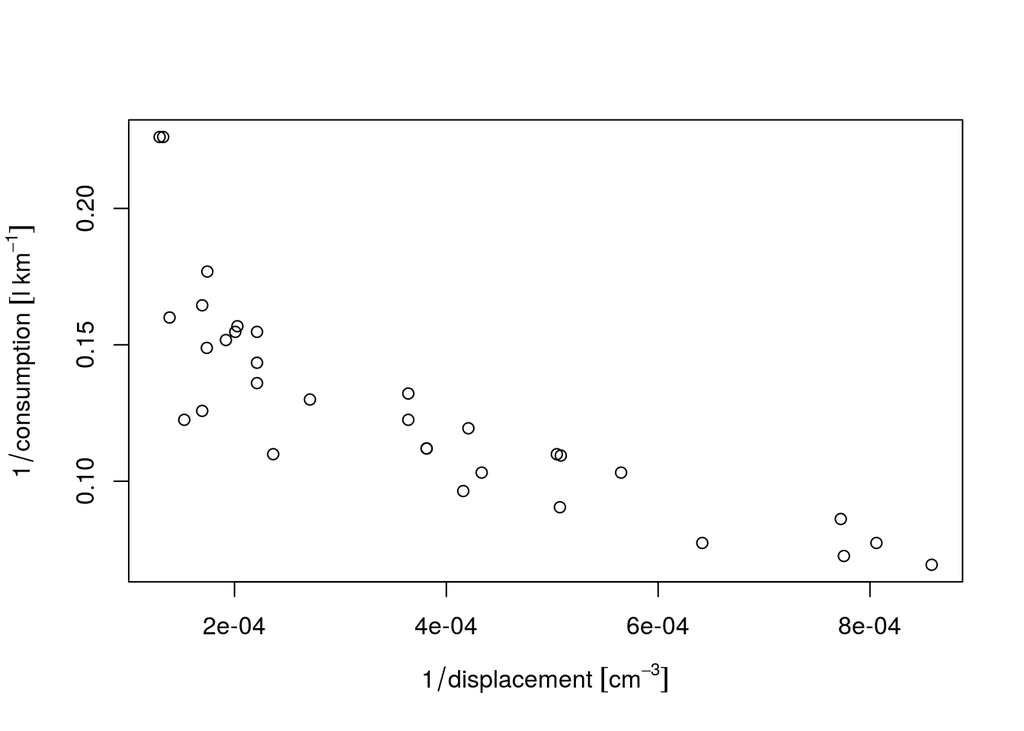

```r
par(mar = par("mar") + c(0, .3, 0, 0))
plot(1/displacement, 1/consumption)
```

## How to do this with ggplot?

We can of course plot these data by dropping units:

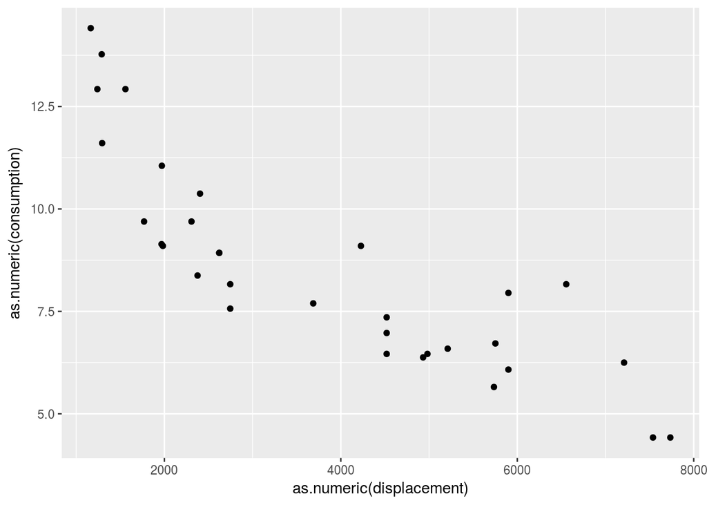

```r
library(ggplot2)
ggplot() + geom_point(aes(x = as.numeric(displacement),
    y = as.numeric(consumption)))
```

but that doesn’t show us units. Giving the units as variables gives an error:

```r
ggplot() + geom_point(aes(x = displacement, y = consumption))
```

```
## Error in Ops.units(x, range[1]): both operands of the expression should be "units" objects
```

(I could make that error go away by letting `units` drop the requirement that in a comparison both sides should have compatible units, which of course would be wrong.)

We can then go all the way with

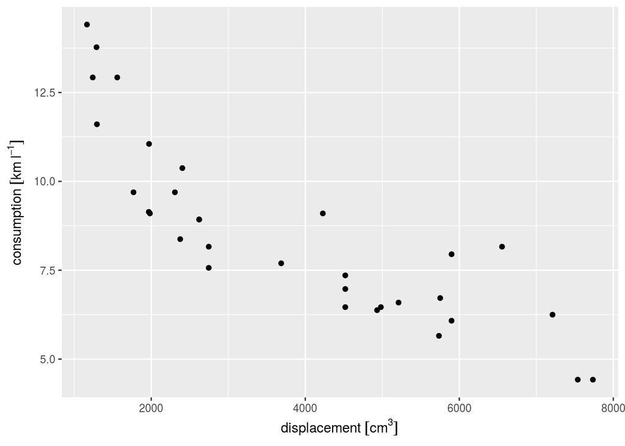

```r
ggplot() + geom_point(aes(x = as.numeric(displacement),
    y = as.numeric(consumption))) +
    xlab(make_unit_label("displacement", displacement)) +
    ylab(make_unit_label("consumption", consumption))
```

which at least doesn’t cut off the left label, but feels too convoluted and error-prone.

Oh ggplot gurus, who can help us out, here? How can we obtain that last plot by

```r
ggplot() + geom_point(aes(x = displacement, y = consumption))
```

?

## Related posts/articles

- [Does R understand physical quantities?](http://r-spatial.org/r/2016/06/10/units.html)
- [Measurement units in R now simplify](http://r-spatial.org/r/2016/08/16/units2.html)
- [Measurement units for R](https://cran.r-project.org/web/packages/units/vignettes/measurement_units_in_R.pdf) (R Journal draft manuscript, package vignette)